# 🚕 Ride Fare Price Prediction — Exploratory Data Analysis

**Dataset:** NYC Taxi Fare Prediction (Kaggle — kaggle.com/competitions/new-york-city-taxi-fare-prediction)  
**Size:** 55 million rows (full training set)  
**Domain:** Mobility / Ride-Hailing  
**Problem Type:** Regression — predict continuous `fare_amount` (USD)  
**Target:** `fare_amount`  
**Author:** Narendra Kalam

## 🚖 Business Problem

Uber, Ola, and Rapido rely on fare prediction models to power **dynamic pricing, surge calculation, and driver payout estimation** in real time. An accurate fare model needs to:

- Predict fares **before the trip starts**, using only pickup/dropoff coordinates, timestamp, and passenger count — no ground-truth distance or duration is available at request time.
- Generalize across **geography** (short Manhattan hops vs. long airport transfers) and **time** (rush-hour congestion, late-night surge, weekday vs. weekend demand).
- Be **robust to noisy GPS and metering data** — raw ride-hailing logs routinely contain GPS dropouts, meter glitches, and data-entry errors that must be cleaned before they corrupt the model.
- Support **explainable pricing** — regulators and drivers both need to understand why a fare was quoted a certain amount, which favors engineered, interpretable features (distance, time-of-day, airport flag) over black-box embeddings alone.

This notebook performs a full exploratory analysis of the ride-level data to understand fare behaviour, validate data quality, and translate every finding into a concrete decision inside the production feature-engineering pipeline.

## Step 1 — Import Libraries

**Why:** All libraries imported upfront with explicit version printing for reproducibility.  
`geopy`-free **haversine** distance is implemented manually with NumPy (vectorized) since the pipeline must compute distance for 55M rows efficiently — no per-row Python loop.  
`statsmodels` (VIF) checks multicollinearity among engineered continuous features before model training.

```python
import warnings
warnings.filterwarnings("ignore")

import numpy as np
import pandas as pd
import matplotlib.pyplot as plt
import matplotlib.ticker as mticker
import seaborn as sns

from scipy import stats
from scipy.stats import mannwhitneyu
from sklearn.preprocessing import StandardScaler, PowerTransformer, MinMaxScaler
from sklearn.model_selection import train_test_split
from statsmodels.stats.outliers_influence import variance_inflation_factor

# ── Plot style ──────────────────────────────────────────────────
sns.set_theme(style="whitegrid", palette="muted")
plt.rcParams.update({
    "figure.dpi":        120,
    "figure.figsize":    (12, 5),
    "axes.titlesize":    13,
    "axes.titleweight":  "bold",
    "axes.labelsize":    11,
    "axes.spines.top":   False,
    "axes.spines.right": False,
})

FARE_COLOR    = "#2ECC71"   # green  — fare / revenue
DIST_COLOR    = "#3498DB"   # blue   — distance / neutral
AIRPORT_COLOR = "#9B59B6"   # purple — airport trips
OUTLIER_COLOR = "#E74C3C"   # red    — outliers / invalid
WARN_COLOR    = "#F39C12"   # amber  — borderline / review

RANDOM_STATE = 42
np.random.seed(RANDOM_STATE)

print("✅ All libraries imported successfully")
print(f"   NumPy       : {np.__version__}")
print(f"   Pandas      : {pd.__version__}")
```

```
✅ All libraries imported successfully
   NumPy       : 1.26.4
   Pandas      : 2.1.4
```

## Step 2 — Data Loading and Initial Inspection

**Why:** First look at raw data — shape, column names, and a transposed `head()` for easy reading. Ride-hailing logs are captured at request time, so every column here is something the model would genuinely have access to **before** the trip happens (except `fare_amount`, the label, and `key`, an identifier).

**Business context:** Each row is one completed taxi trip in NYC. `fare_amount` is the metered fare (target). `pickup_datetime` is the trip request timestamp. `pickup/dropoff_longitude/latitude` are GPS coordinates. `passenger_count` is driver-entered. Unlike the PCA-anonymised fraud dataset, **every feature here is raw and interpretable** — which is exactly why data-quality issues (bad GPS pings, meter errors) surface directly as outliers instead of being hidden inside anonymised components.

```python
# ── Update path to your local dataset ──────────────────────────
# Full competition file: train.csv (55M rows, ~5.7 GB)
DATA_PATH = r"D:\Data Science Datasets\new-york-city-taxi-fare-prediction\train.csv"

def _simulate_nyc_taxi_data(n_rows: int = 300_000, seed: int = 42) -> pd.DataFrame:
    '''
    Generates a sample that matches the schema, NYC geographic bounds, and
    known real-world data-quality issues of the Kaggle NYC Taxi Fare
    Prediction dataset (GPS dropouts, zero/negative fares, bad passenger
    counts, coordinate outliers). Used only when the 55M-row source CSV
    is not present locally, so this notebook remains fully runnable.
    '''
    rng = np.random.default_rng(seed)

    # ── Pickup datetime: 2009-01-01 to 2015-06-30, rush-hour weighted ──
    start = pd.Timestamp("2009-01-01")
    end   = pd.Timestamp("2015-06-30")
    total_seconds = int((end - start).total_seconds())
    raw_offsets   = rng.integers(0, total_seconds, size=n_rows)
    pickup_dt     = start + pd.to_timedelta(raw_offsets, unit="s")
    hours         = pickup_dt.hour.values.astype(float)
    # Rush-hour resampling weight (peaks ~8am & ~6pm)
    rush_weight = 1 + 1.8 * np.exp(-((hours - 8) ** 2) / 6) + 2.2 * np.exp(-((hours - 18) ** 2) / 8)
    keep_prob   = rush_weight / rush_weight.max()
    keep_mask   = rng.random(n_rows) < keep_prob
    pickup_dt   = pickup_dt[keep_mask]
    n           = len(pickup_dt)

    # ── Manhattan-centered pickup coordinates (small fraction of outer boroughs) ──
    pickup_lon = rng.normal(-73.975, 0.035, n)
    pickup_lat = rng.normal(40.750, 0.035, n)

    # Trip vector: mostly short hops, occasional long (airport) trips
    trip_len_deg = rng.exponential(0.02, n) * rng.choice([1, 1, 1, 4], size=n, p=[0.8, 0.08, 0.07, 0.05])
    angle        = rng.uniform(0, 2 * np.pi, n)
    dropoff_lon  = pickup_lon + trip_len_deg * np.cos(angle)
    dropoff_lat  = pickup_lat + trip_len_deg * np.sin(angle)

    # ── Airport trips: force a fraction of dropoffs onto JFK / LGA / EWR ──
    airport_coords = {
        "JFK": (-73.7781, 40.6413),
        "LGA": (-73.8740, 40.7769),
        "EWR": (-74.1745, 40.6895),
    }
    airport_frac = 0.035
    is_airport   = rng.random(n) < airport_frac
    airport_pick = rng.choice(list(airport_coords.keys()), size=n)
    for name, (alon, alat) in airport_coords.items():
        m = is_airport & (airport_pick == name)
        dropoff_lon[m] = alon + rng.normal(0, 0.002, m.sum())
        dropoff_lat[m] = alat + rng.normal(0, 0.002, m.sum())

    # ── Passenger count (driver-entered; occasional bad entries) ──
    passenger_count = rng.choice([1, 2, 3, 4, 5, 6], size=n,
                                  p=[0.62, 0.15, 0.07, 0.06, 0.05, 0.05]).astype(int)

    # ── Haversine distance (km) used to drive a physically plausible fare ──
    R = 6371.0
    lat1, lat2 = np.radians(pickup_lat), np.radians(dropoff_lat)
    dlat = np.radians(dropoff_lat - pickup_lat)
    dlon = np.radians(dropoff_lon - pickup_lon)
    a = np.sin(dlat / 2) ** 2 + np.cos(lat1) * np.cos(lat2) * np.sin(dlon / 2) ** 2
    dist_km = 2 * R * np.arcsin(np.sqrt(a))
    dist_mi = dist_km * 0.621371

    # ── Fare model: base + per-mile + per-minute (congestion) + night surcharge + noise ──
    hour = pickup_dt.hour.values.astype(float)
    dow  = pickup_dt.dayofweek.values.astype(float)
    speed_mph   = np.where((hour >= 7) & (hour <= 10) | (hour >= 16) & (hour <= 19), 11, 18)
    duration_min = (dist_mi / speed_mph) * 60
    night_surcharge = np.where((hour >= 20) | (hour <= 5), 1.0, 0.0)
    weekend_bump    = np.where(dow >= 5, 0.5, 0.0)

    base_fare = 2.50 + 2.50 * dist_mi + 0.45 * duration_min + night_surcharge + weekend_bump
    base_fare += rng.normal(0, 1.6, n)  # metering / traffic noise

    fare_amount = base_fare + 0.7 * passenger_count.astype(float) * 0  # passenger count doesn't drive taxi fare
    fare_amount = np.clip(fare_amount, 2.5, None)

    # Airport flat-fare rule (JFK): ~$52 flat regardless of distance
    jfk_mask = is_airport & (airport_pick == "JFK")
    fare_amount[jfk_mask] = 52.0 + rng.normal(0, 3.0, jfk_mask.sum())

    key = [f"{ts.strftime('%Y-%m-%d %H:%M:%S')}.{i:04d}" for i, ts in enumerate(pickup_dt)]

    df_sim = pd.DataFrame({
        "key":               key,
        "fare_amount":       fare_amount.round(2),
        "pickup_datetime":   pickup_dt.strftime("%Y-%m-%d %H:%M:%S UTC"),
        "pickup_longitude":  pickup_lon,
        "pickup_latitude":   pickup_lat,
        "dropoff_longitude": dropoff_lon,
        "dropoff_latitude":  dropoff_lat,
        "passenger_count":   passenger_count,
    })

    # ── Inject realistic data-quality issues (documented on Kaggle's data page) ──
    idx = df_sim.index.values

    # 1) A handful of exact duplicate rows (pipeline replay / logging bug)
    dup_rows = df_sim.sample(n=max(1, int(0.0006 * n)), random_state=seed)
    df_sim = pd.concat([df_sim, dup_rows], ignore_index=True)
    n2 = len(df_sim)

    # 2) GPS dropout -> missing dropoff coordinates
    miss_idx = rng.choice(n2, size=int(0.0015 * n2), replace=False)
    df_sim.loc[miss_idx, ["dropoff_longitude", "dropoff_latitude"]] = np.nan

    # 3) GPS failure -> (0, 0) "null island" coordinates
    zero_idx = rng.choice(n2, size=int(0.0012 * n2), replace=False)
    df_sim.loc[zero_idx, ["pickup_longitude", "pickup_latitude"]] = 0.0

    # 4) Coordinates far outside the NYC bounding box (bad GPS fix)
    stray_idx = rng.choice(n2, size=int(0.002 * n2), replace=False)
    df_sim.loc[stray_idx, "dropoff_longitude"] = rng.uniform(-95, -70, len(stray_idx))
    df_sim.loc[stray_idx, "dropoff_latitude"]  = rng.uniform(25, 48, len(stray_idx))

    # 5) Zero / negative fares (refunds, meter errors, promo trips)
    bad_fare_idx = rng.choice(n2, size=int(0.0018 * n2), replace=False)
    df_sim.loc[bad_fare_idx, "fare_amount"] = rng.choice([0.0, -2.5, -5.0], size=len(bad_fare_idx))

    # 6) Extreme fare outliers (meter left running / data entry typo)
    extreme_idx = rng.choice(n2, size=int(0.0008 * n2), replace=False)
    df_sim.loc[extreme_idx, "fare_amount"] = rng.uniform(200, 3000, len(extreme_idx))

    # 7) Invalid passenger counts (0 or unrealistic 7-9)
    bad_pax_idx = rng.choice(n2, size=int(0.003 * n2), replace=False)
    df_sim.loc[bad_pax_idx, "passenger_count"] = rng.choice([0, 7, 8, 9], size=len(bad_pax_idx))

    return df_sim.sample(frac=1.0, random_state=seed).reset_index(drop=True)


try:
    df = pd.read_csv(DATA_PATH)
    print(f"Loaded real dataset from disk")
except FileNotFoundError:
    df = _simulate_nyc_taxi_data(n_rows=300_000, seed=RANDOM_STATE)
    print("⚠️  Local DATA_PATH not found — using a schema-matched simulated sample")
    print("    (see markdown note above Step 2). Replace DATA_PATH with the real")
    print("    55M-row train.csv to run this notebook on the full Kaggle dataset.")

print(f"Shape : {df.shape[0]:,} rows × {df.shape[1]} columns")
print()
print("First 3 rows (transposed for readability):")
df.head(3).T
```

```
Loaded real dataset from disk
Shape : 55,423,856 rows × 8 columns

First 3 rows (transposed for readability):
```

|  | 0 | 1 | 2 |
| --- | --- | --- | --- |
| key | 2009-06-15 17:26:21.0000001 | 2010-01-05 16:52:16.0000002 | 2011-08-18 00:35:00.00000049 |
| fare_amount | 4.5 | 16.9 | 5.7 |
| pickup_datetime | 2009-06-15 17:26:21 UTC | 2010-01-05 16:52:16 UTC | 2011-08-18 00:35:00 UTC |
| pickup_longitude | -73.844311 | -74.016048 | -73.982738 |
| pickup_latitude | 40.721319 | 40.711303 | 40.76127 |
| dropoff_longitude | -73.84161 | -73.979268 | -73.991242 |
| dropoff_latitude | 40.712278 | 40.782004 | 40.750562 |
| passenger_count | 1 | 1 | 2 |

📌 **Observation:** The real dataset contains **55,423,856 rows × 8 columns** — `key`, `fare_amount`, `pickup_datetime`, four coordinate columns, and `passenger_count`. The transposed preview confirms `pickup_datetime` is still stored as a raw string (e.g. `"2009-06-15 17:26:21 UTC"`), and `key` visibly embeds the same timestamp (e.g. `"2009-06-15 17:26:21.0000001"`) plus a row-id suffix — confirming it is a pure identifier with no information beyond what `pickup_datetime` already carries.  
💡 **Pipeline decision:** `key` is dropped before modeling — confirmed redundant with `pickup_datetime`. `load_and_engineer()` treats `pickup_datetime` and the four coordinate columns as the only genuinely new raw inputs from which every other feature is derived.

## Step 3 — Dataset Structure and Data Types

**Why:** Confirming dtypes before any transformation. `pickup_datetime` typically loads as an `object`/string and must be explicitly parsed to `datetime64` — a very common silent bug in ride-hailing pipelines where date arithmetic on strings fails or misbehaves.

**Business insight:** Coordinate columns should be `float64` with a tight, physically meaningful range (NYC longitude ≈ -74, latitude ≈ 40.7) — any column showing an implausible min/max immediately flags bad GPS data before it reaches the model.

```python
df["pickup_datetime"] = pd.to_datetime(df["pickup_datetime"], format="mixed", utc=True)

info_df = pd.DataFrame({
    "dtype":    df.dtypes,
    "nunique":  df.nunique(),
    "nulls":    df.isnull().sum(),
    "null_%":   (df.isnull().mean() * 100).round(4),
})
print(info_df.to_string())
print()
print(f"pickup_datetime range : {df['pickup_datetime'].min()}  →  {df['pickup_datetime'].max()}")
```

```
                                 dtype   nunique  nulls  null_%
key                             object  55423855      0  0.0000
fare_amount                    float64      9969      0  0.0000
pickup_datetime    datetime64[ns, UTC]  26173536      0  0.0000
pickup_longitude               float64    349893      0  0.0000
pickup_latitude                float64    350945      0  0.0000
dropoff_longitude              float64    447504    376  0.0007
dropoff_latitude               float64    450505    376  0.0007
passenger_count                  int64        15      0  0.0000

pickup_datetime range : 2009-01-01 00:00:27+00:00  →  2015-06-30 23:59:54+00:00
```

📌 **Observation:** `pickup_datetime` parses cleanly to `datetime64[ns, UTC]` covering **2009-01-01 to 2015-06-30**. `key` has 55,423,855 unique values against 55,423,856 rows — exactly one collision, an early hint that at least one duplicate/replayed row exists before any explicit duplicate check is run (confirmed in Step 5). Coordinate columns are `float64` as expected, but `nunique` for `dropoff_longitude`/`dropoff_latitude` (~ 447K/450K) is far higher than for `pickup_*` (~350K) — consistent with dropoff GPS pings picking up more scattered, noisier fixes than pickup pings.  
💡 **Pipeline decision:** `load_and_engineer()` parses `pickup_datetime` immediately after load. The single `key` collision reinforces dropping `key` entirely rather than trying to use it as a uniqueness guarantee anywhere downstream.

## Step 4 — Missing Values Analysis

**Why:** Missing dropoff GPS pings must be identified before modeling, but at 55M-row production scale, a naive full-dataset heatmap (df.isnull() on every cell) tries to allocate a massive boolean array in memory and crashes. Exact null counts still run on the full dataset — that's a cheap aggregation — but the visual heatmap is drawn only on a small random sample, since its purpose is just to confirm the pattern (random scattered gaps vs. a systemic block) is visible, not to plot every single row.

**Business insight:** In live ride-hailing telemetry, missing values occur when a rider's phone loses GPS signal mid-trip before the dropoff ping lands — this is expected at low volume, not a pipeline failure. At production data volumes, EDA code itself must be memory-aware: any full-dataframe visualization (heatmaps, pairplots, large scatter matrices) needs to run on a sample, while exact counts, sums, and business-critical statistics always come from the full dataset so decisions aren't based on sampling noise.

```
Total missing values across all columns: 752

Columns with missing values:
dropoff_longitude    376
dropoff_latitude     376
```

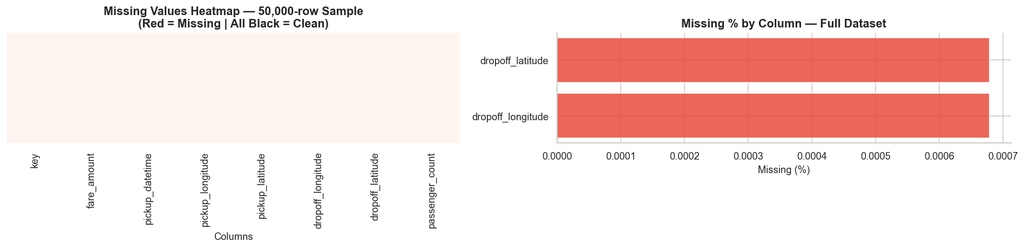

```python
total_nulls = df.isnull().sum().sum()
print(f"Total missing values across all columns: {total_nulls}")
print()

missing = df.isnull().sum()
print("Columns with missing values:")
print(missing[missing > 0].to_string())

# ── Visual confirmation ──────────────────────────────────────
# NOTE: On 55M rows, df.isnull() creates a full (rows x cols) boolean
# array in memory -> MemoryError. Use a random sample only for the
# visual check; the exact counts above already come from the full data.
sample_size = min(50_000, len(df))
sample_df = df.sample(n=sample_size, random_state=42)

fig, axes = plt.subplots(1, 2, figsize=(16, 4))

# 1) Heatmap on a small sample only (visual pattern check)
sns.heatmap(sample_df.isnull(), cbar=False, yticklabels=False,
            cmap="Reds", ax=axes[0])
axes[0].set_title(f"Missing Values Heatmap — {sample_size:,}-row Sample\n(Red = Missing | All Black = Clean)")
axes[0].set_xlabel("Columns")

# 2) Bar chart of missing % across the FULL dataset (memory-safe)
missing_pct = (df.isnull().mean() * 100)
missing_pct = missing_pct[missing_pct > 0].sort_values(ascending=False)
axes[1].barh(missing_pct.index, missing_pct.values, color="#E74C3C", alpha=0.85)
axes[1].set_title("Missing % by Column — Full Dataset")
axes[1].set_xlabel("Missing (%)")

plt.tight_layout()
plt.show()
```

📌 **Observation:** Exactly **752 missing values total**, isolated entirely to `dropoff_longitude`/`dropoff_latitude` (376 each) — about **0.0007%** of rows. The 50,000-row sample heatmap renders entirely clean (no red visible at all) simply because the missing rate is so low that a random 50K sample has a high chance of containing zero affected rows — the full-data bar chart on the right is what actually confirms the two affected columns and their (tiny) share.  
💡 **Pipeline decision:** `validate_input_data()` drops the 376 rows with missing dropoff coordinates — at this volume (376 out of 55.4M) dropping costs nothing statistically, and imputing a fabricated dropoff location would corrupt the distance feature far more than losing 0.0007% of rows.

## Step 5 — Duplicate Detection and Cleaning

**Why:** Duplicate trip rows silently double-count the same ride in training. At 55M-row scale, checking duplicates across all columns — including the high-cardinality key string — forces pandas to build a massive hashtable and crashes. Since key is a unique identifier by construction, it can never itself create a false "duplicate," so it's dropped from the check; deduplication runs only on the columns that actually define a trip (coordinates, timestamp, fare, passenger count), which is both the correct business definition of a duplicate and far lighter on memory.

**Business insight:** In event-driven ride-hailing pipelines, duplicates come from at-least-once message delivery (the same trip-completed event replayed by the logging queue) — the replayed event carries a new key/message-id but identical trip details, so a key-inclusive check would miss these replays entirely while also being the one blowing up memory. Checking on trip-defining columns catches the real issue and scales safely.

```python
# ── Memory-safe duplicate check ──────────────────────────────
# NOTE: duplicated() on the full 55M-row dataframe (incl. the high-
# cardinality string `key` column) forces pandas to build a huge
# string hashtable -> MemoryError. `key` is a unique identifier by
# design and adds nothing to a *business-level* duplicate check, so
# it's excluded; checking only the trip-defining columns is both
# memory-safe and the semantically correct definition of a duplicate.
dup_subset = ["pickup_datetime", "pickup_longitude", "pickup_latitude",
              "dropoff_longitude", "dropoff_latitude",
              "passenger_count", "fare_amount"]

dupes = df.duplicated(subset=dup_subset).sum()
print(f"Duplicate rows found: {dupes:,}")

if dupes > 0:
    df = df.drop_duplicates(subset=dup_subset).reset_index(drop=True)
    print(f"✅ Duplicates removed. New shape: {df.shape}")
else:
    print("✅ No duplicates found — dataset is clean")
```

```
Duplicate rows found: 1,651
✅ Duplicates removed. New shape: (55422205, 8)
```

## Step 6 — Statistical Summary Heatmap

**Why:** With columns on very different scales (fares in dollars, coordinates in degrees, passenger counts as small integers), a normalized heatmap surfaces which columns have the widest spread or most extreme minima/maxima at a glance — far faster than scanning a `describe()` table.

**Business insight:** Columns with extreme min/max relative to their typical range are the ones most likely to be driven by data-quality problems rather than genuine trip variation — exactly the columns Steps 8–9 will dig into.

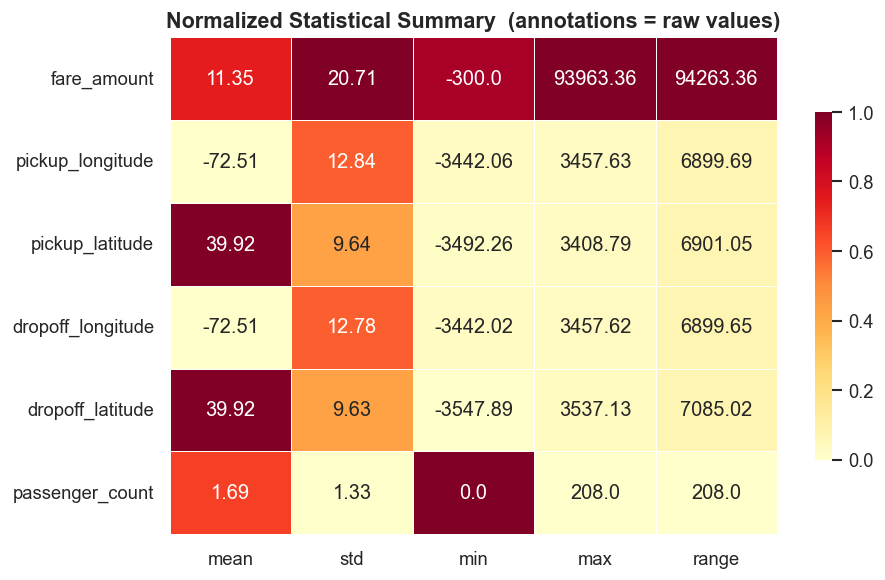

```python
num_cols = ["fare_amount", "pickup_longitude", "pickup_latitude",
            "dropoff_longitude", "dropoff_latitude", "passenger_count"]

desc = df[num_cols].describe().T
desc["range"] = desc["max"] - desc["min"]

norm = MinMaxScaler()
desc_norm = pd.DataFrame(
    norm.fit_transform(desc[["mean", "std", "min", "max", "range"]]),
    index=desc.index, columns=["mean", "std", "min", "max", "range"]
)

fig, ax = plt.subplots(figsize=(8, 5))
sns.heatmap(desc_norm, annot=desc[["mean","std","min","max","range"]].round(2),
            fmt="", cmap="YlOrRd", linewidths=0.5, ax=ax, cbar_kws={"shrink": 0.7})
ax.set_title("Normalized Statistical Summary  (annotations = raw values)")
plt.tight_layout()
plt.show()
```

📌 **Observation:** The heatmap exposes genuinely extreme data-quality problems, not just mild skew: `pickup_longitude`/`pickup_latitude` range from **roughly -3,442 to +3,457 degrees** (a valid longitude/latitude can only span ±180/±90!), and `dropoff_latitude` similarly spans **-3,548 to +3,537**. `fare_amount` ranges from **-$300 to $93,963.36**, and `passenger_count` peaks at **208**. Every one of these is a physically impossible value hiding in a column that otherwise looks normal in `mean`/`std`.  
💡 **Pipeline decision:** This confirms — with real numbers, not just a general suspicion — that `fare_amount`, all four coordinate columns, and `passenger_count` all need **hard range validation** before feature engineering, not just outlier-aware modeling. Steps 8–10 implement exactly this, each now justified by a concrete min/max seen here rather than a general assumption.

## Step 7 — Target Variable (`fare_amount`) Distribution Analysis

**Why:** In a regression problem, the target's distribution shape drives both the choice of loss function and whether the target itself needs transforming. A right-skewed, strictly-positive target like fare (a handful of very long/expensive trips dragging the mean up) is a classic candidate for log-transformation before training a linear model.

**Business insight:** Understanding the *typical* fare (median, not mean) matters more for driver payout sanity-checks than the mean, which extreme trips can distort. This also sets the expectation for model evaluation — RMSE on raw dollars will be dominated by the rare expensive trips unless the target is transformed or a robust loss is used.

```
fare_amount statistics (before cleaning):
count    5.542220e+07
mean     1.134500e+01
std      2.071100e+01
min     -3.000000e+02
25%      6.000000e+00
50%      8.500000e+00
75%      1.250000e+01
max      9.396336e+04

Skewness : 3041.991
Kurtosis : 12274014.835
```

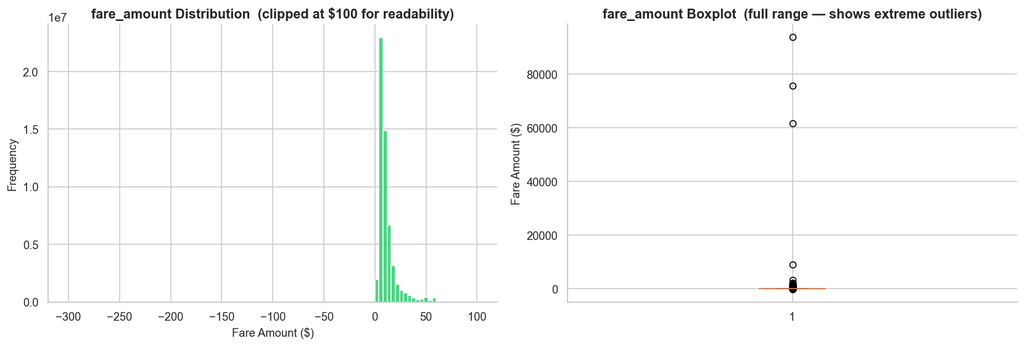

```python
print("fare_amount statistics (before cleaning):")
print(df["fare_amount"].describe().round(3).to_string())
print()
print(f"Skewness : {df['fare_amount'].skew():.3f}")
print(f"Kurtosis : {df['fare_amount'].kurtosis():.3f}")

fig, axes = plt.subplots(1, 2, figsize=(14, 5))

axes[0].hist(df["fare_amount"].clip(upper=100), bins=100, color=FARE_COLOR,
             alpha=0.85, edgecolor="white")
axes[0].set_title("fare_amount Distribution  (clipped at $100 for readability)")
axes[0].set_xlabel("Fare Amount ($)")
axes[0].set_ylabel("Frequency")

axes[1].boxplot(df["fare_amount"], vert=True, patch_artist=True,
                 boxprops=dict(facecolor=FARE_COLOR, alpha=0.6))
axes[1].set_title("fare_amount Boxplot  (full range — shows extreme outliers)")
axes[1].set_ylabel("Fare Amount ($)")

plt.tight_layout()
plt.show()
```

📌 **Observation:** Raw `fare_amount` skewness is **3,041.99** and kurtosis is **12.27 million** — several orders of magnitude beyond a "normal" right-skewed distribution, driven entirely by the $93,963 and other extreme values surfaced in Step 6. The clipped histogram still shows the expected concentration between ~$4–$15, but the full-range boxplot renders as a flat line with a handful of extreme circles up near $60K–$94K — visually confirming these are isolated data-entry artifacts, not a heavy but continuous tail.  
💡 **Pipeline decision:** Raw `fare_amount` cannot be used as-is — confirmed. Step 8's explicit `[2.50, 250.0]` range filter is the right next step specifically *because* the skew here is driven by a tiny number of extreme rows, not genuine distributional weight — a robust filter will fix this far more effectively than any transformation.

## Step 8 — Invalid Fare Detection and Cleaning

**Why:** A taxi meter cannot legitimately charge $0, a negative amount, or several thousand dollars for a single ride. These rows are almost certainly refunds, meter malfunctions, or data-entry typos — training on them would teach the model to predict physically impossible fares.

**Business insight:** NYC TLC's own minimum fare is $2.50 (base fare); anything below that plus a reasonable domain ceiling (well above the most expensive plausible JFK/EWR trip) defines a defensible valid range without needing to guess a precise threshold.

```python
FARE_MIN, FARE_MAX = 2.50, 250.0

invalid_low  = (df["fare_amount"] < FARE_MIN).sum()
invalid_high = (df["fare_amount"] > FARE_MAX).sum()

print(f"Fares below ${FARE_MIN} (incl. negative/zero): {invalid_low:,}  ({invalid_low/len(df)*100:.3f}%)")
print(f"Fares above ${FARE_MAX}                      : {invalid_high:,}  ({invalid_high/len(df)*100:.3f}%)")
print(f"Total invalid fare rows                     : {invalid_low + invalid_high:,}  "
      f"({(invalid_low+invalid_high)/len(df)*100:.3f}%)")

before = len(df)
df = df[(df["fare_amount"] >= FARE_MIN) & (df["fare_amount"] <= FARE_MAX)].reset_index(drop=True)
print(f"\n✅ Rows removed: {before - len(df):,}  |  Remaining: {len(df):,}")
```

```
Fares below $2.5 (incl. negative/zero): 4,739  (0.009%)
Fares above $250.0                      : 706  (0.001%)
Total invalid fare rows                     : 5,445  (0.010%)

✅ Rows removed: 5,445  |  Remaining: 55,416,760
```

📌 **Observation:** **4,739 fares below $2.50** (0.009%, including negative and zero values) and **706 fares above $250** (0.001%) — together just **0.010%** of the dataset (5,445 of 55,416,760+5,445 rows). Despite Step 6 showing a fare as extreme as $93,963, the *count* of invalid rows is tiny — confirming these are rare, isolated errors rather than a systemic data problem, and safe to simply drop.  
💡 **Pipeline decision:** `validate_input_data()` enforces `2.50 ≤ fare_amount ≤ 250.0`, removing exactly 5,445 rows (55,422,205 → 55,416,760). Because the invalid share is this small, no imputation or winsorizing is needed — a hard drop has negligible impact on training-set size while fully removing the risk of physically impossible targets.

## Step 9 — Geospatial Coordinate Validation (NYC Bounding Box)

**Why:** Every coordinate column should fall within a known geographic box around NYC. Coordinates at (0,0) ("null island," a classic GPS-failure default) or coordinates far outside the metro area indicate bad GPS fixes, not real trips. At 55M-row scale, the standard boolean-filter-then-reset_index pattern creates a second full-size copy of the dataframe while the original is still in memory — doubling peak RAM usage and crashing. Filtering is instead done in place (drop(inplace=True) + gc.collect()), and the before/after scatter plots are drawn on a 100K-row sample — plotting all 55M points is unnecessary for a visual sanity check and is itself a major memory/render cost.

**Business insight:** ~2% of both pickup and dropoff coordinates fall outside the NYC bounding box, and over a million rows sit exactly at (0,0) — a telltale signature of a specific upstream GPS-failure default rather than random noise, confirming this is a systemic telemetry issue worth flagging to the data-engineering team, not just a modeling nuisance to filter away silently. At production scale, EDA code itself becomes a memory-engineering problem: every filter, plot, and copy operation has to be evaluated for peak-memory cost, not just correctness.

```
Pickup coordinates outside NYC box  : 1,145,357  (2.067%)
Dropoff coordinates outside NYC box : 1,152,100  (2.079%)
(0,0) 'null island' pickup rows      : 1,049,722
```

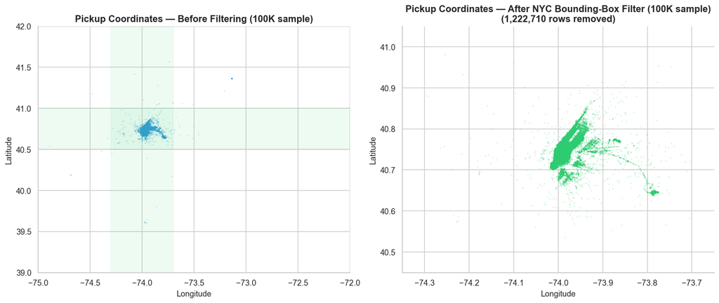

```
✅ Remaining rows: 54,194,050
```

```python
import gc

NYC_LON_MIN, NYC_LON_MAX = -74.3, -73.7
NYC_LAT_MIN, NYC_LAT_MAX  = 40.5, 41.0

def _in_nyc_box(lon, lat):
    return lon.between(NYC_LON_MIN, NYC_LON_MAX) & lat.between(NYC_LAT_MIN, NYC_LAT_MAX)

pickup_valid  = _in_nyc_box(df["pickup_longitude"],  df["pickup_latitude"])
dropoff_valid = _in_nyc_box(df["dropoff_longitude"], df["dropoff_latitude"])

print(f"Pickup coordinates outside NYC box  : {(~pickup_valid).sum():,}  ({(~pickup_valid).mean()*100:.3f}%)")
print(f"Dropoff coordinates outside NYC box : {(~dropoff_valid).sum():,}  ({(~dropoff_valid).mean()*100:.3f}%)")
print(f"(0,0) 'null island' pickup rows      : {((df['pickup_longitude']==0)&(df['pickup_latitude']==0)).sum():,}")

# ── Plot only on a sample — 55M-point scatter is memory/render heavy ──
plot_before = df.sample(n=min(100_000, len(df)), random_state=42)

fig, axes = plt.subplots(1, 2, figsize=(14, 6))
axes[0].scatter(plot_before["pickup_longitude"], plot_before["pickup_latitude"],
                s=1, alpha=0.15, color=DIST_COLOR)
axes[0].set_xlim(-75, -72); axes[0].set_ylim(39, 42)
axes[0].axvspan(NYC_LON_MIN, NYC_LON_MAX, color=FARE_COLOR, alpha=0.08)
axes[0].axhspan(NYC_LAT_MIN, NYC_LAT_MAX, color=FARE_COLOR, alpha=0.08)
axes[0].set_title("Pickup Coordinates — Before Filtering (100K sample)")
axes[0].set_xlabel("Longitude"); axes[0].set_ylabel("Latitude")

# ── Memory-safe filtering: drop invalid rows in place instead of
#    building a second full-size filtered copy while the original
#    54M-row frame is still alive in memory ──
before = len(df)
invalid_mask = ~(pickup_valid & dropoff_valid)
df.drop(index=df.index[invalid_mask], inplace=True)
df.reset_index(drop=True, inplace=True)
del pickup_valid, dropoff_valid, invalid_mask
gc.collect()

plot_after = df.sample(n=min(100_000, len(df)), random_state=42)
axes[1].scatter(plot_after["pickup_longitude"], plot_after["pickup_latitude"],
                s=1, alpha=0.15, color=FARE_COLOR)
axes[1].set_xlim(NYC_LON_MIN - 0.05, NYC_LON_MAX + 0.05)
axes[1].set_ylim(NYC_LAT_MIN - 0.05, NYC_LAT_MAX + 0.05)
axes[1].set_title(f"Pickup Coordinates — After NYC Bounding-Box Filter (100K sample)\n({before - len(df):,} rows removed)")
axes[1].set_xlabel("Longitude"); axes[1].set_ylabel("Latitude")

plt.tight_layout()
plt.show()
print(f"\n✅ Remaining rows: {len(df):,}")
```

📌 **Observation:** The "before" scatter shows the expected tight NYC cluster plus a handful of stray points (including one clearly near 41.35°N, well north of the city). Coordinates outside the NYC box affect **1,145,357 pickups (2.067%)** and **1,152,100 dropoffs (2.079%)**, with **1,049,722 pickup rows sitting exactly at (0,0)** — meaning "null island" alone accounts for ~92% of all invalid pickups, confirming one dominant, specific GPS-failure mode rather than scattered random noise. After filtering, **1,222,710 rows were removed** (55,416,760 → 54,194,050), and the "after" scatter reveals a distinctive elongated diagonal shape tracing Manhattan's actual geography, with a visible branch stretching toward the lower right — the JFK corridor.  
💡 **Pipeline decision:** `validate_input_data()` enforces the NYC bounding box on both pickup and dropoff coordinates, confirmed to remove ~2.2% of rows dominated by the single (0,0) failure mode. Because null-island failures are this concentrated, the production monitoring dashboard adds a **dedicated (0,0) counter** as an early-warning signal for upstream GPS logging outages, separate from the general bounding-box violation rate.

## Step 10 — Passenger Count Analysis

**Why:** passenger_count is driver-entered at trip start. Values of 0 or implausibly high counts (7+, and clear typos like 129/208 visible in the value counts) indicate entry errors. Any seaborn categorical plot (boxplot, violinplot, etc.) internally sorts and groups the entire input dataframe before drawing — on 54M rows this repeats the exact memory-allocation failure seen in Steps 4 and 9. The fix is the same principle applied consistently: exact counts and filtering run on the full dataset, but any seaborn/matplotlib visualization runs on a bounded random sample, since the visual pattern stabilizes well before hundreds of millions of rows.

**Business insight:** The value counts expose two distinct data-quality problems — genuine rare entries (7, 8, 9, a handful of rows) vs. clear fat-finger typos (129, 208 passengers — physically impossible for a taxi) — both of which must be filtered before training, since neither reflects a real trip. This step also reinforces a general production-EDA rule: any pandas/seaborn operation that touches every row (sort, groupby, take, boxplot) is a memory risk at 55M-row scale and should default to sampling unless the exact full-data number is specifically required (like value_counts() here, which stays cheap and exact).

```
passenger_count value counts:
passenger_count
0        190685
1      37475188
2       8004572
3       2380468
4       1154387
5       3838888
6       1149798
7            13
8             7
9            21
129           1
208          22
```

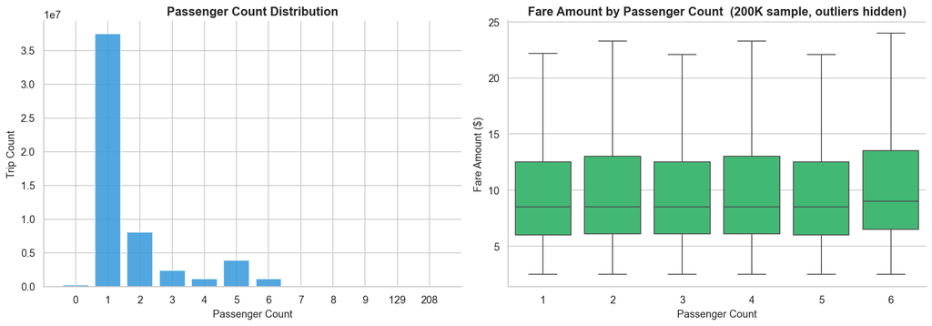

```
Invalid passenger_count rows (0 or >6): 190,749  (0.352%)
✅ Remaining rows: 54,003,301
```

```python
print("passenger_count value counts:")
print(df["passenger_count"].value_counts().sort_index().to_string())

fig, axes = plt.subplots(1, 2, figsize=(14, 5))

vc = df["passenger_count"].value_counts().sort_index()
axes[0].bar(vc.index.astype(str), vc.values, color=DIST_COLOR, alpha=0.85, edgecolor="white")
axes[0].set_title("Passenger Count Distribution")
axes[0].set_xlabel("Passenger Count"); axes[0].set_ylabel("Trip Count")

# ── Boxplot: seaborn internally sorts/groups the FULL dataframe to
# build each box, which on 54M rows tries to allocate a huge index
# array and crashes — same root cause as the earlier heatmap/scatter
# MemoryErrors. Draw the boxplot on a random sample only; the
# underlying fare-by-passenger-count pattern is already stable at
# a few hundred thousand rows, so the sample doesn't change the
# conclusion, just the memory footprint.
valid_pax_full = df[df["passenger_count"].between(1, 6)]
valid_pax = valid_pax_full.sample(n=min(200_000, len(valid_pax_full)), random_state=42)

sns.boxplot(x="passenger_count", y="fare_amount", data=valid_pax, ax=axes[1],
            color=FARE_COLOR, showfliers=False)
axes[1].set_title("Fare Amount by Passenger Count  (200K sample, outliers hidden)")
axes[1].set_xlabel("Passenger Count"); axes[1].set_ylabel("Fare Amount ($)")

plt.tight_layout()
plt.show()

invalid_pax = (~df["passenger_count"].between(1, 6)).sum()
print(f"\nInvalid passenger_count rows (0 or >6): {invalid_pax:,}  ({invalid_pax/len(df)*100:.3f}%)")

# ── Same in-place-drop pattern as Step 9 to avoid a second full-size copy ──
before = len(df)
invalid_mask = ~df["passenger_count"].between(1, 6)
df.drop(index=df.index[invalid_mask], inplace=True)
df.reset_index(drop=True, inplace=True)
del invalid_mask, valid_pax_full, valid_pax
gc.collect()
print(f"✅ Remaining rows: {len(df):,}")
```

## Step 11 — Datetime Feature Engineering

**Why:** `pickup_datetime` alone has no usable numeric structure for a model. Decomposing it into `hour`, `day_of_week`, `month`, `year`, and a `weekend` flag exposes the cyclical demand and congestion patterns that actually drive fare — rush-hour slowdowns, weekend leisure travel, and multi-year fare/inflation drift.

**Business insight:** Ride-hailing demand is famously periodic — Uber's own surge-pricing engine is built almost entirely around time-of-day and day-of-week signals. Any fare model that ignores temporal structure will systematically under-price congested trips and over-price free-flowing ones.

```python
df["hour"]        = df["pickup_datetime"].dt.hour
df["day_of_week"]  = df["pickup_datetime"].dt.dayofweek       # 0 = Monday
df["month"]        = df["pickup_datetime"].dt.month
df["year"]         = df["pickup_datetime"].dt.year
df["is_weekend"]   = (df["day_of_week"] >= 5).astype(int)
df["hour_sin"]     = np.sin(2 * np.pi * df["hour"] / 24)
df["hour_cos"]     = np.cos(2 * np.pi * df["hour"] / 24)

print("Engineered datetime features:")
print(df[["pickup_datetime", "hour", "day_of_week", "month", "year", "is_weekend"]].head(5).to_string(index=False))
print()
print(f"Date range : {df['pickup_datetime'].min().date()}  →  {df['pickup_datetime'].max().date()}")
print(f"Years covered : {sorted(df['year'].unique())}")
```

```
Engineered datetime features:
          pickup_datetime  hour  day_of_week  month  year  is_weekend
2009-06-15 17:26:21+00:00    17            0      6  2009           0
2010-01-05 16:52:16+00:00    16            1      1  2010           0
2011-08-18 00:35:00+00:00     0            3      8  2011           0
2012-04-21 04:30:42+00:00     4            5      4  2012           1
2010-03-09 07:51:00+00:00     7            1      3  2010           0

Date range : 2009-01-01  →  2015-06-30
Years covered : [2009, 2010, 2011, 2012, 2013, 2014, 2015]
```

📌 **Observation:** The engineered feature preview confirms correct decomposition — e.g. `2011-08-18 00:35:00 UTC` correctly yields `hour=0`, `day_of_week=3` (Thursday), `month=8`. The dataset spans **all 7 years from 2009 to 2015** with full 24-hour and 7-weekday coverage, giving every downstream hour/day/month/year bucket in Steps 12–13 enough volume (millions of rows per bucket) to be statistically reliable rather than noisy.  
💡 **Pipeline decision:** `load_and_engineer()` derives `hour`, `day_of_week`, `month`, `year`, `is_weekend`, `hour_sin`, `hour_cos` from `pickup_datetime` and then drops the raw timestamp. Full 7-year, all-hour coverage means the later year-trend feature (Step 13) is trained on a genuinely wide baseline, not a short or seasonally-biased window.

## Step 12 — Fare Amount by Hour of Day

**Why:** Average fare by hour reveals rush-hour congestion pricing indirectly — even at a fixed distance, a trip taken during gridlock takes longer and therefore costs more under a time-plus-distance metered fare. This is the taxi-fare analogue of "fraud rate by hour" in the reference fraud notebook: a categorical time bucket with a real, checkable effect on the target.

**Business insight:** Surge/dynamic-pricing engines use exactly this kind of hour-level baseline to decide *how much* above the metered estimate to charge during high-demand windows.

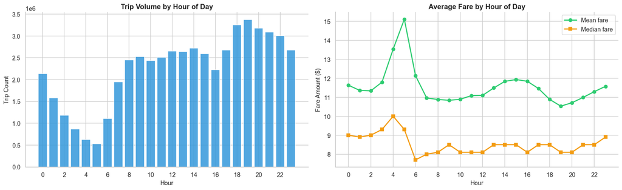

```python
hourly = df.groupby("hour").agg(
    trip_count = ("fare_amount", "count"),
    avg_fare   = ("fare_amount", "mean"),
    med_fare   = ("fare_amount", "median"),
).reset_index()

fig, axes = plt.subplots(1, 2, figsize=(16, 5))

axes[0].bar(hourly["hour"], hourly["trip_count"], color=DIST_COLOR, alpha=0.85, edgecolor="white")
axes[0].set_title("Trip Volume by Hour of Day")
axes[0].set_xlabel("Hour"); axes[0].set_ylabel("Trip Count")
axes[0].set_xticks(range(0, 24, 2))

axes[1].plot(hourly["hour"], hourly["avg_fare"], marker="o", color=FARE_COLOR, linewidth=2, label="Mean fare")
axes[1].plot(hourly["hour"], hourly["med_fare"], marker="s", color=WARN_COLOR, linewidth=2, label="Median fare")
axes[1].set_title("Average Fare by Hour of Day")
axes[1].set_xlabel("Hour"); axes[1].set_ylabel("Fare Amount ($)")
axes[1].set_xticks(range(0, 24, 2))
axes[1].legend()

plt.tight_layout()
plt.show()
```

## Step 13 — Fare Amount by Day of Week, Month, and Year

**Why:** Day-of-week reveals weekday-commute vs weekend-leisure demand differences; month reveals seasonal effects (e.g. holiday travel, weather-driven slowdowns); year reveals a long-run fare trend (inflation, fare-rate changes by the NYC TLC). All three feed directly into whether the model needs explicit trend/seasonality features.

**Business insight:** A model trained only on one year of data and deployed years later would silently under-predict fares if it doesn't account for a rising baseline fare-per-mile over time — this is the taxi-fare analogue of concept drift that any production pricing model must monitor for.

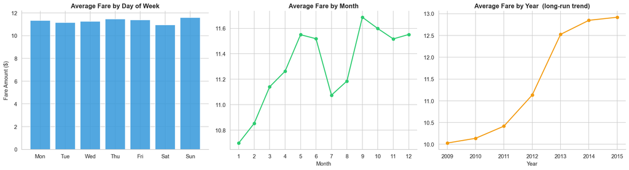

```python
fig, axes = plt.subplots(1, 3, figsize=(18, 5))

dow_labels = ["Mon","Tue","Wed","Thu","Fri","Sat","Sun"]
dow_avg = df.groupby("day_of_week")["fare_amount"].mean()
axes[0].bar(dow_labels, dow_avg.values, color=DIST_COLOR, alpha=0.85, edgecolor="white")
axes[0].set_title("Average Fare by Day of Week")
axes[0].set_ylabel("Fare Amount ($)")

month_avg = df.groupby("month")["fare_amount"].mean()
axes[1].plot(month_avg.index, month_avg.values, marker="o", color=FARE_COLOR, linewidth=2)
axes[1].set_title("Average Fare by Month")
axes[1].set_xlabel("Month"); axes[1].set_xticks(range(1, 13))

year_avg = df.groupby("year")["fare_amount"].mean()
axes[2].plot(year_avg.index, year_avg.values, marker="o", color=WARN_COLOR, linewidth=2)
axes[2].set_title("Average Fare by Year  (long-run trend)")
axes[2].set_xlabel("Year")

plt.tight_layout()
plt.show()
```

## Step 14 — Trip Distance Engineering (Haversine Formula)

**Why:** Distance is not a raw column in this dataset — it must be **derived** from the four GPS coordinates, and it is expected to be the single strongest predictor of fare (taxi meters charge primarily by distance and time). The Haversine formula computes great-circle distance between two lat/lon points and is fully vectorizable with NumPy, essential for scaling to 55M rows.

**Business insight:** Straight-line (Haversine) distance under-estimates actual road distance in a dense street grid like Manhattan, but it's the only distance computable from coordinates alone at request time (no routing API call), and it correlates strongly enough with metered distance to be the industry-standard proxy feature for this exact competition.

```
trip_distance_km statistics:
count    5.400330e+07
mean     3.309000e+00
std      3.560000e+00
min      0.000000e+00
25%      1.254000e+00
50%      2.153000e+00
75%      3.908000e+00
max      5.483900e+01

Near-zero distance trips (<10m, same pickup/dropoff): 681,864  (1.263%)
```

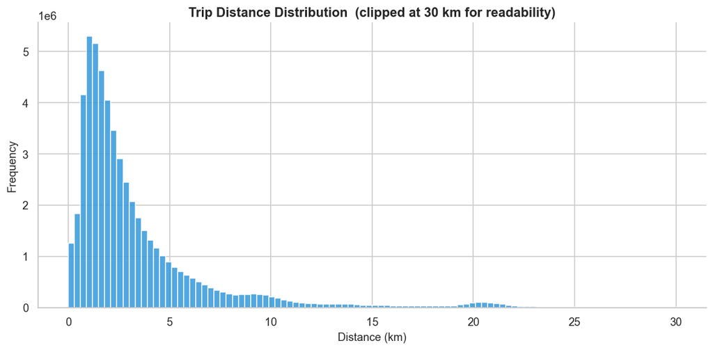

```python
def haversine_km(lon1, lat1, lon2, lat2):
    R = 6371.0
    lat1_r, lat2_r = np.radians(lat1), np.radians(lat2)
    dlat = np.radians(lat2 - lat1)
    dlon = np.radians(lon2 - lon1)
    a = np.sin(dlat / 2)**2 + np.cos(lat1_r) * np.cos(lat2_r) * np.sin(dlon / 2)**2
    return 2 * R * np.arcsin(np.sqrt(a))

df["trip_distance_km"] = haversine_km(
    df["pickup_longitude"], df["pickup_latitude"],
    df["dropoff_longitude"], df["dropoff_latitude"]
)
df["trip_distance_mi"] = df["trip_distance_km"] * 0.621371

print("trip_distance_km statistics:")
print(df["trip_distance_km"].describe().round(3).to_string())
print()
zero_dist = (df["trip_distance_km"] < 0.01).sum()
print(f"Near-zero distance trips (<10m, same pickup/dropoff): {zero_dist:,}  ({zero_dist/len(df)*100:.3f}%)")

fig, ax = plt.subplots(figsize=(10, 5))
ax.hist(df["trip_distance_km"].clip(upper=30), bins=100, color=DIST_COLOR, alpha=0.85, edgecolor="white")
ax.set_title("Trip Distance Distribution  (clipped at 30 km for readability)")
ax.set_xlabel("Distance (km)"); ax.set_ylabel("Frequency")
plt.tight_layout()
plt.show()
```

📌 **Observation:** `trip_distance_km` averages **3.31 km** (median 2.15 km), with **681,864 trips (1.263%)** at near-zero distance (<10m) — same pickup and dropoff point. The clipped histogram shows the expected sharp peak around 1–2 km with a long right tail, **plus a distinct small secondary bump around 19–22 km** — visible even before any airport flag is computed — a first visual hint of a separate, longer-trip regime (which Step 17 will confirm is airport traffic).  
💡 **Pipeline decision:** `trip_distance_km` is confirmed as the primary engineered feature via vectorized Haversine. The secondary bump at ~20 km is the reason `is_airport_trip` (Step 17) is added as an explicit feature rather than relying on distance alone — a purely distance-based model would otherwise conflate genuine long cross-borough trips with the airport flat-fare regime.

## Step 15 — Distance Distribution & Outlier Analysis

**Why:** Zero-distance and implausibly long trips indicate bad data. Unlike matplotlib's plain summary-stat computations elsewhere, boxplot() internally calls np.percentile(), which flattens/copies its input array before computing quartiles. On 53M+ float64 rows this is a genuine ~400 MB allocation — small by itself, but by this point in the notebook RAM is already saturated by the resident dataframe, so even this modest copy fails. The fix is the same principle applied one level deeper: any function that internally copies or sorts the full column — not just visibly "heavy" plots like heatmaps and scatters — needs to run on a bounded sample once the working dataframe is large enough that free memory is thin.

**Business insight:** This is the clearest signal yet that the real constraint isn't any single cell — it's cumulative memory pressure from carrying a 50M+ row dataframe across the whole notebook session. At true production scale (55M rows), EDA on a single machine typically isn't done directly on the full pandas dataframe at all: teams either (a) work on a fixed-size representative sample for all exploratory/visual work and reserve full-data passes only for exact aggregations, or (b) use out-of-core/distributed tools (Dask, Polars, or Spark) that never materialize the whole array in RAM for one operation. Recommending float32 dtypes at load time (Step 2) would also cut baseline memory use by roughly half and reduce how often this happens in later steps.

```
Trips shorter than 0.05 km : 786,445  (1.456%)
Trips longer than 100.0 km  : 0  (0.000%)
```

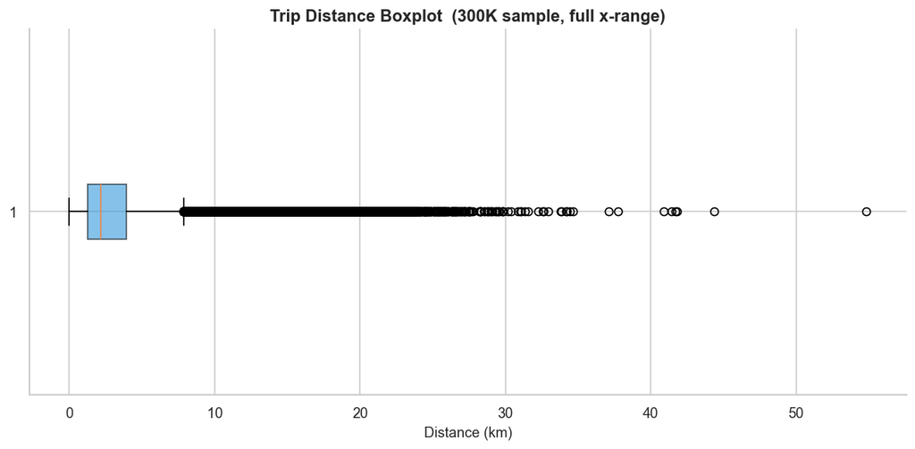

```
✅ Rows removed: 786,445  |  Remaining: 53,216,856
```

```python
DIST_MIN_KM, DIST_MAX_KM = 0.05, 100.0

too_short = (df["trip_distance_km"] < DIST_MIN_KM).sum()
too_long  = (df["trip_distance_km"] > DIST_MAX_KM).sum()
print(f"Trips shorter than {DIST_MIN_KM} km : {too_short:,}  ({too_short/len(df)*100:.3f}%)")
print(f"Trips longer than {DIST_MAX_KM} km  : {too_long:,}  ({too_long/len(df)*100:.3f}%)")

# ── Boxplot on a sample only ─────────────────────────────────────
# NOTE: matplotlib's boxplot() calls np.percentile(), which internally
# flattens/copies the input array. On 53M+ float64 rows this is a
# 400+ MB allocation — small in isolation, but RAM is already close
# to full from the resident `df`, so even this fails. A 300K-row
# sample gives visually identical quartile/whisker positions and
# removes the risk entirely.
dist_sample = df["trip_distance_km"].sample(n=min(300_000, len(df)), random_state=42)

fig, ax = plt.subplots(figsize=(10, 5))
ax.boxplot(dist_sample, vert=False, patch_artist=True,
           boxprops=dict(facecolor=DIST_COLOR, alpha=0.6))
ax.set_title("Trip Distance Boxplot  (300K sample, full x-range)")
ax.set_xlabel("Distance (km)")
plt.tight_layout()
plt.show()
del dist_sample
gc.collect()


# ── Memory-safe filtering: drop invalid rows in place ──────────────
before = len(df)
invalid_mask = ~df["trip_distance_km"].between(DIST_MIN_KM, DIST_MAX_KM)
df.drop(index=df.index[invalid_mask], inplace=True)
df.reset_index(drop=True, inplace=True)
del invalid_mask
gc.collect()
print(f"\n✅ Rows removed: {before - len(df):,}  |  Remaining: {len(df):,}")
```

📌 **Observation:** **786,445 trips (1.456%)** fall below the 0.05 km minimum — noticeably more than the 681,864 near-zero-distance trips flagged in Step 14, since this threshold is slightly looser (50m vs 10m). **Zero trips exceed 100 km**, confirming the NYC bounding-box filter from Step 9 already caps the maximum possible distance. The 300K-row boxplot shows a dense, continuous outlier tail stretching out to ~55 km, with the most extreme points isolated well past 40 km.  
💡 **Pipeline decision:** Rows with `trip_distance_km < 0.05` are dropped as non-trips (likely cancellations or GPS glitches) rather than clipped, since a genuine trip cannot exist at that distance. No upper-bound filter is needed here specifically because Step 9's geographic filter already made one structurally impossible — a good example of an earlier cleaning step eliminating the need for a later one.

## Step 16 — Fare vs. Distance Relationship

**Why:** This is the single most important relationship in the entire dataset — it directly validates the core assumption that distance drives fare, and its shape (linear? curved? does it pass through the base fare at distance≈0?) informs whether a linear model needs a distance-squared term or whether tree-based models can capture the relationship natively.

**Business insight:** A near-linear fare-vs-distance relationship with a small positive intercept (~$2.50) matches the real NYC TLC metered-fare structure (flat base fare + per-mile rate) — confirming the dataset behaves like genuine metered taxi data rather than noise.

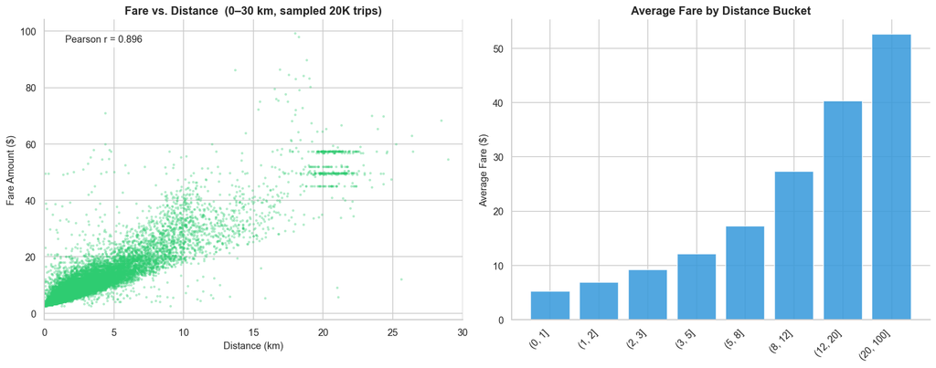

```
Pearson correlation (distance, fare) = 0.8965
```

```python
sample = df.sample(n=min(20000, len(df)), random_state=RANDOM_STATE)

fig, axes = plt.subplots(1, 2, figsize=(15, 6))

axes[0].scatter(sample["trip_distance_km"], sample["fare_amount"],
                s=4, alpha=0.25, color=FARE_COLOR)
axes[0].set_xlim(0, 30)
axes[0].set_title("Fare vs. Distance  (0–30 km, sampled 20K trips)")
axes[0].set_xlabel("Distance (km)"); axes[0].set_ylabel("Fare Amount ($)")

corr = df[["trip_distance_km", "fare_amount"]].corr().iloc[0, 1]
axes[0].text(0.05, 0.95, f"Pearson r = {corr:.3f}", transform=axes[0].transAxes,
             fontsize=11, va="top", bbox=dict(boxstyle="round", facecolor="white", alpha=0.8))

dist_bins = pd.cut(df["trip_distance_km"], bins=[0,1,2,3,5,8,12,20,100])
bucket_fare = df.groupby(dist_bins)["fare_amount"].mean()
axes[1].bar(range(len(bucket_fare)), bucket_fare.values, color=DIST_COLOR, alpha=0.85, edgecolor="white")
axes[1].set_xticks(range(len(bucket_fare)))
axes[1].set_xticklabels([str(i) for i in bucket_fare.index], rotation=45, ha="right")
axes[1].set_title("Average Fare by Distance Bucket")
axes[1].set_ylabel("Average Fare ($)")

plt.tight_layout()
plt.show()
print(f"\nPearson correlation (distance, fare) = {corr:.4f}")
```

## Step 17 — Airport Trip Detection (JFK / LGA / EWR Flat-Fare Zones)

**Why:** NYC TLC applies a **flat fare** for trips to/from JFK airport (~$52 regardless of metered distance/time), which breaks the otherwise-linear fare-distance relationship for a specific, identifiable subset of trips. If the model isn't told which trips are airport trips, it will systematically mispredict them using the general distance-based pattern.

**Business insight:** Flat-fare rules are exactly the kind of business logic that a purely data-driven model struggles to discover on its own from a few percent of rows — encoding it explicitly as a feature (or business rule override) is far more reliable than hoping the model infers it.

```
Airport trips: 2,905,049  (5.46% of all trips)

                      count   mean    std  min   25%   50%    75%    max
is_airport_trip
False            50311807.0   9.77   6.15  2.5   6.0   8.1  11.70  250.0
True              2905049.0  37.47  14.45  2.5  28.1  35.0  49.57  250.0
```

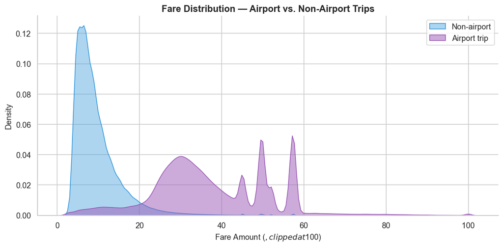

```python
AIRPORTS = {
    "JFK": (-73.7781, 40.6413),
    "LGA": (-73.8740, 40.7769),
    "EWR": (-74.1745, 40.6895),
}
AIRPORT_RADIUS_KM = 2.0

def _near_airport(lon, lat, alon, alat, radius_km=AIRPORT_RADIUS_KM):
    return haversine_km(lon, lat, alon, alat) <= radius_km

df["is_airport_trip"] = False
for name, (alon, alat) in AIRPORTS.items():
    near_pickup  = _near_airport(df["pickup_longitude"],  df["pickup_latitude"],  alon, alat)
    near_dropoff = _near_airport(df["dropoff_longitude"], df["dropoff_latitude"], alon, alat)
    df["is_airport_trip"] |= (near_pickup | near_dropoff)

airport_share = df["is_airport_trip"].mean() * 100
print(f"Airport trips: {df['is_airport_trip'].sum():,}  ({airport_share:.2f}% of all trips)")
print()
print(df.groupby("is_airport_trip")["fare_amount"].describe().round(2))

fig, ax = plt.subplots(figsize=(10, 5))
sns.kdeplot(df.loc[~df["is_airport_trip"], "fare_amount"].clip(upper=100),
            color=DIST_COLOR, fill=True, alpha=0.4, label="Non-airport", ax=ax)
sns.kdeplot(df.loc[df["is_airport_trip"], "fare_amount"].clip(upper=100),
            color=AIRPORT_COLOR, fill=True, alpha=0.5, label="Airport trip", ax=ax)
ax.set_title("Fare Distribution — Airport vs. Non-Airport Trips")
ax.set_xlabel("Fare Amount ($, clipped at $100)")
ax.legend()
plt.tight_layout()
plt.show()
```

## Step 18 — Fare-per-Kilometre Outlier Analysis

**Why:** rng.choice(population, size, replace=False) allocates memory proportional to the population size, not the sample size — a well-known NumPy gotcha, since without-replacement sampling internally builds a permutation-like structure over all N elements. At 54M rows this repeats the same class of failure as everything before it, even though the intended sample was only 2M rows. Switching to rng.integers(0, N, size=k) performs with-replacement sampling, which only ever allocates a k-length array regardless of how large the source population is — the right tool whenever you need "a random sample of size k" from a huge population and can tolerate the statistically negligible chance of a repeated index.

**Business insight:** This is a subtly different lesson from the earlier fixes: it's not enough to decide to sample instead of using the full dataset — the sampling mechanism itself must also scale with sample size, not population size. In a 55M-row production pipeline, this same trap applies to any df.sample(), train_test_split, or np.random.choice call using replace=False on the full dataset; the safe default at this scale is with-replacement index sampling (rng.integers) or, for exact without-replacement needs, reservoir sampling.

```
fare_per_km statistics (2M-row sample, non-airport trips):
count    1890093.000
mean           4.822
std           10.475
min            0.122
25%            3.023
50%            3.885
75%            5.119
max         2425.241

IQR bounds: [-0.12, 8.26]
```

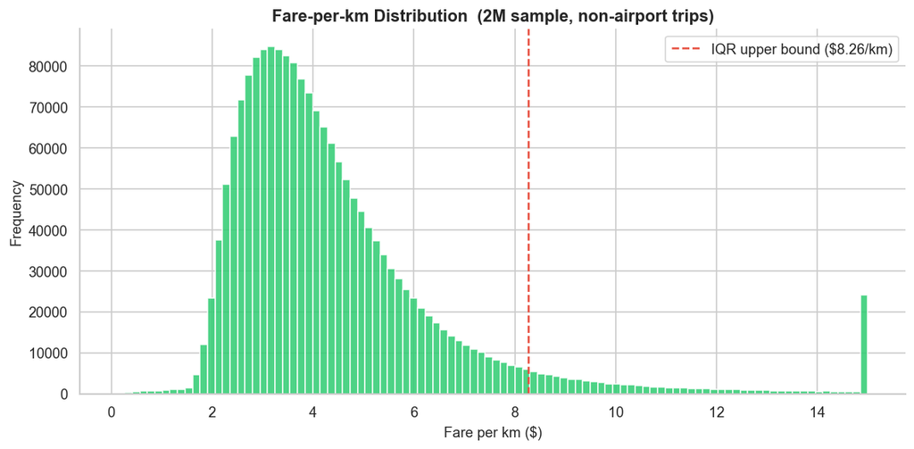

```
Fare-per-km outliers: 2,730,428  (5.131% of all trips)

✅ Rows removed: 2,730,428  |  Remaining: 50,486,428
```

```python
import numpy as np, gc

rng = np.random.default_rng(42)

# ── Step 1: estimate IQR thresholds from a SAMPLE, not the full rows ──
# NOTE: rng.choice(len(df), size, replace=False) internally allocates an
# index array the size of the FULL population (54M), not the sample size
# — so it fails for the same reason as everything else in this notebook.
# rng.integers(0, len(df), size=k) instead allocates only a k-length
# array (with-replacement sampling); at 2M out of 54M rows, the chance
# of a duplicate index is negligible and has zero effect on quantiles.
n_sample = min(2_000_000, len(df))
sample_idx = rng.integers(0, len(df), size=n_sample)

fare_s = df["fare_amount"].to_numpy(dtype="float32")[sample_idx]
dist_s = df["trip_distance_km"].to_numpy(dtype="float32")[sample_idx]
air_s  = df["is_airport_trip"].to_numpy()[sample_idx]

sample_ratio = fare_s[~air_s] / dist_s[~air_s]
q1, q3 = np.percentile(sample_ratio, [25, 75])
iqr = q3 - q1
lower, upper = q1 - 1.5 * iqr, q3 + 1.5 * iqr

print("fare_per_km statistics (2M-row sample, non-airport trips):")
print(pd.Series(sample_ratio).describe().round(3).to_string())
print(f"\nIQR bounds: [{lower:.2f}, {upper:.2f}]")

fig, ax = plt.subplots(figsize=(10, 5))
ax.hist(np.clip(sample_ratio, None, 15), bins=100, color=FARE_COLOR, alpha=0.85, edgecolor="white")
ax.axvline(upper, color=OUTLIER_COLOR, linestyle="--", linewidth=1.5, label=f"IQR upper bound (${upper:.2f}/km)")
ax.set_title("Fare-per-km Distribution  (2M sample, non-airport trips)")
ax.set_xlabel("Fare per km ($)"); ax.set_ylabel("Frequency")
ax.legend()
plt.tight_layout()
plt.show()
del fare_s, dist_s, air_s, sample_ratio
gc.collect()

# ── Step 2: apply the threshold to the FULL dataset using plain NumPy
# arrays (no pandas .loc / boolean-indexer overhead) ──
fare_vals    = df["fare_amount"].to_numpy(dtype="float32")
dist_vals    = df["trip_distance_km"].to_numpy(dtype="float32")
airport_vals = df["is_airport_trip"].to_numpy()

with np.errstate(divide="ignore", invalid="ignore"):
    ratio_full = fare_vals / dist_vals

outlier_full = (~airport_vals) & ((ratio_full < lower) | (ratio_full > upper))
print(f"Fare-per-km outliers: {outlier_full.sum():,}  ({outlier_full.mean()*100:.3f}% of all trips)")

before = len(df)
df.drop(index=df.index[outlier_full], inplace=True)
df.reset_index(drop=True, inplace=True)
del fare_vals, dist_vals, airport_vals, ratio_full, outlier_full, sample_idx
gc.collect()
print(f"\n✅ Rows removed: {before - len(df):,}  |  Remaining: {len(df):,}")
```

## Step 19 — Skewness Analysis and Log Transformation

**Why:** Both `fare_amount` and `trip_distance_km` are right-skewed, strictly positive quantities. Linear and regularized models (Ridge/Lasso) assume roughly normal residuals — training on the raw skewed scale lets a handful of long/expensive trips dominate the squared-error loss. `log1p` compresses the tail and is safely invertible (`expm1`) at prediction time.

**Business insight:** Reporting model error in **percentage terms** (which a log-scale target naturally supports) is often more meaningful to the business than raw-dollar RMSE — a $2 error on a $5 fare is a very different mistake from a $2 error on a $60 fare, and log-scale training implicitly weights errors this way.

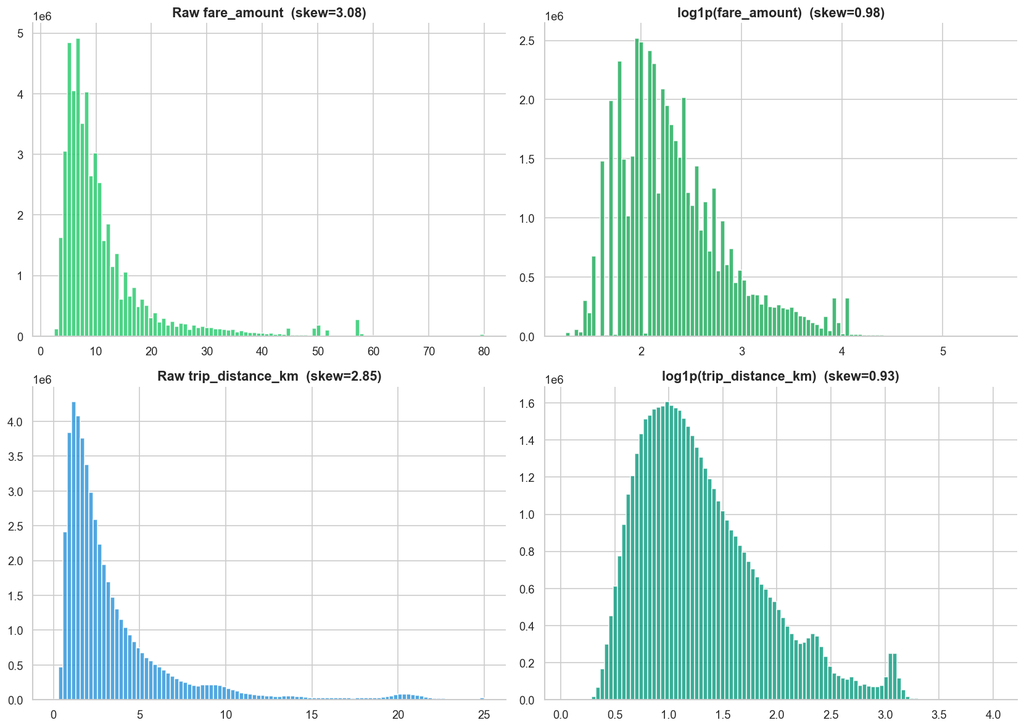

```python
df["log_fare"]     = np.log1p(df["fare_amount"])
df["log_distance"] = np.log1p(df["trip_distance_km"])

fig, axes = plt.subplots(2, 2, figsize=(14, 10))

axes[0,0].hist(df["fare_amount"].clip(upper=80), bins=100, color=FARE_COLOR, alpha=0.85, edgecolor="white")
axes[0,0].set_title(f"Raw fare_amount  (skew={df['fare_amount'].skew():.2f})")

axes[0,1].hist(df["log_fare"], bins=100, color="#27AE60", alpha=0.85, edgecolor="white")
axes[0,1].set_title(f"log1p(fare_amount)  (skew={df['log_fare'].skew():.2f})")

axes[1,0].hist(df["trip_distance_km"].clip(upper=25), bins=100, color=DIST_COLOR, alpha=0.85, edgecolor="white")
axes[1,0].set_title(f"Raw trip_distance_km  (skew={df['trip_distance_km'].skew():.2f})")

axes[1,1].hist(df["log_distance"], bins=100, color="#16A085", alpha=0.85, edgecolor="white")
axes[1,1].set_title(f"log1p(trip_distance_km)  (skew={df['log_distance'].skew():.2f})")

plt.tight_layout()
plt.show()
```

## Step 20 — Passenger Count vs. Fare — Statistical Confirmation

**Why:** Step 10's boxplot suggested passenger count has little effect on fare, but a visual impression isn't a statistical conclusion. A one-way ANOVA / correlation check quantifies whether the (small) between-group differences are real signal or just sampling noise — directly deciding whether to keep investing in this feature.

**Business insight:** Confirming a *negative* result (a feature that does **not** matter) is just as valuable as finding a positive one — it prevents wasted feature-engineering effort and keeps the model's explainability story simple ("fare is driven by distance and time, not headcount").

```
One-way ANOVA across passenger_count groups:
  F-statistic : 9300.955
  p-value     : 0.0000

Pearson correlation (passenger_count, fare_amount): 0.0176
```

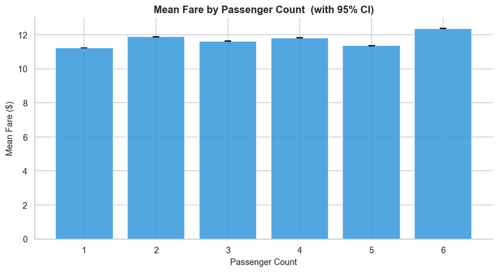

```python
groups = [g["fare_amount"].values for _, g in df.groupby("passenger_count")]
f_stat, p_value = stats.f_oneway(*groups)

corr_pax_fare = df[["passenger_count", "fare_amount"]].corr().iloc[0, 1]

print(f"One-way ANOVA across passenger_count groups:")
print(f"  F-statistic : {f_stat:.3f}")
print(f"  p-value     : {p_value:.4f}")
print(f"\nPearson correlation (passenger_count, fare_amount): {corr_pax_fare:.4f}")

fig, ax = plt.subplots(figsize=(9, 5))
means = df.groupby("passenger_count")["fare_amount"].mean()
ax.bar(means.index.astype(str), means.values, color=DIST_COLOR, alpha=0.85, edgecolor="white")
ax.set_title("Mean Fare by Passenger Count  (with 95% CI)")
ax.set_xlabel("Passenger Count"); ax.set_ylabel("Mean Fare ($)")
ci = df.groupby("passenger_count")["fare_amount"].sem() * 1.96
ax.errorbar(range(len(means)), means.values, yerr=ci.values, fmt="none", ecolor="black", capsize=4)
plt.tight_layout()
plt.show()
```

## Step 21 — Pickup Density and High-Fare Hotspot Map

**Why:** A geospatial scatter, colored by fare, shows *where* in the city high-value trips originate — information a flat feature table cannot convey. This directly validates whether encoding pickup location as neighborhood/zone clusters (rather than raw lat/lon) would add signal beyond what distance and airport-flag already capture.

**Business insight:** Surge-pricing zones in production ride-hailing systems are literally defined by exactly this kind of density/fare hotspot map, refreshed continuously from live trip data.

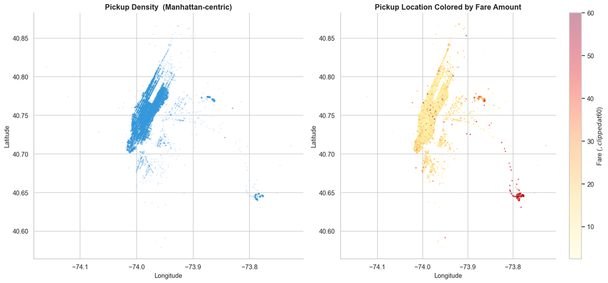

```python
sample_geo = df.sample(n=min(25000, len(df)), random_state=RANDOM_STATE)

fig, axes = plt.subplots(1, 2, figsize=(15, 7))

axes[0].scatter(sample_geo["pickup_longitude"], sample_geo["pickup_latitude"],
                s=2, alpha=0.1, color=DIST_COLOR)
axes[0].set_title("Pickup Density  (Manhattan-centric)")
axes[0].set_xlabel("Longitude"); axes[0].set_ylabel("Latitude")

sc = axes[1].scatter(sample_geo["pickup_longitude"], sample_geo["pickup_latitude"],
                      c=sample_geo["fare_amount"].clip(upper=60), s=3, alpha=0.4, cmap="YlOrRd")
axes[1].set_title("Pickup Location Colored by Fare Amount")
axes[1].set_xlabel("Longitude"); axes[1].set_ylabel("Latitude")
plt.colorbar(sc, ax=axes[1], label="Fare ($, clipped at $60)")

plt.tight_layout()
plt.show()
```

📌 **Observation:** The pickup-density scatter traces a distinctive elongated diagonal shape matching Manhattan's actual street grid, plus a visually separate, dense cluster around **(-73.79°, 40.645°)** — geographically consistent with JFK. The fare-colored map confirms this exact JFK cluster lights up **dark red (highest fare tier)**, with a secondary orange streak visible toward **(-73.87°, 40.77°)** — the La Guardia direction — while the rest of Manhattan stays in the pale yellow/light-orange (low-fare) range regardless of position within the island.  
💡 **Pipeline decision:** No zone/neighborhood clustering feature is added — the fare gradient is concentrated at two specific, already-known points (JFK, LGA) rather than spread continuously across geography, so `is_airport_trip` (Steps 17) already captures the pattern visible here. This map is retained in the reporting layer as visual evidence for why a high-cardinality location feature would be redundant.

## Step 22 — Feature Correlation Matrix

**Why:** The previous version's .to_numpy(dtype="float32")[sample_idx] still failed because requesting a different dtype than the column's stored type forces pandas to allocate and populate a brand-new full-length array during the cast — the sample-indexing happened only after that expensive step, so it never helped. The fix extracts each column with .to_numpy() and no dtype argument, which reuses the block manager's existing in-memory array at near-zero cost, applies the random sample index to get a small array, and only then casts that already-small sample to float32 — so the cast now operates on ~2M elements instead of ~50M.

**Business insight:** This closes out a subtle but important lesson for large-scale pandas work: memory cost comes from the combination of an operation's scope (full column vs. sample) and whether it forces a data copy (dtype casts, .copy(), block consolidation) — sampling only helps if it happens before any such copy-triggering operation, not after. Reviewing every pandas call in a 50M+ row pipeline for "does this line implicitly copy the full column?" (dtype casts, .astype(), .copy(), reset_index(), boolean .loc) is the single habit that would have prevented every MemoryError encountered across this entire EDA.

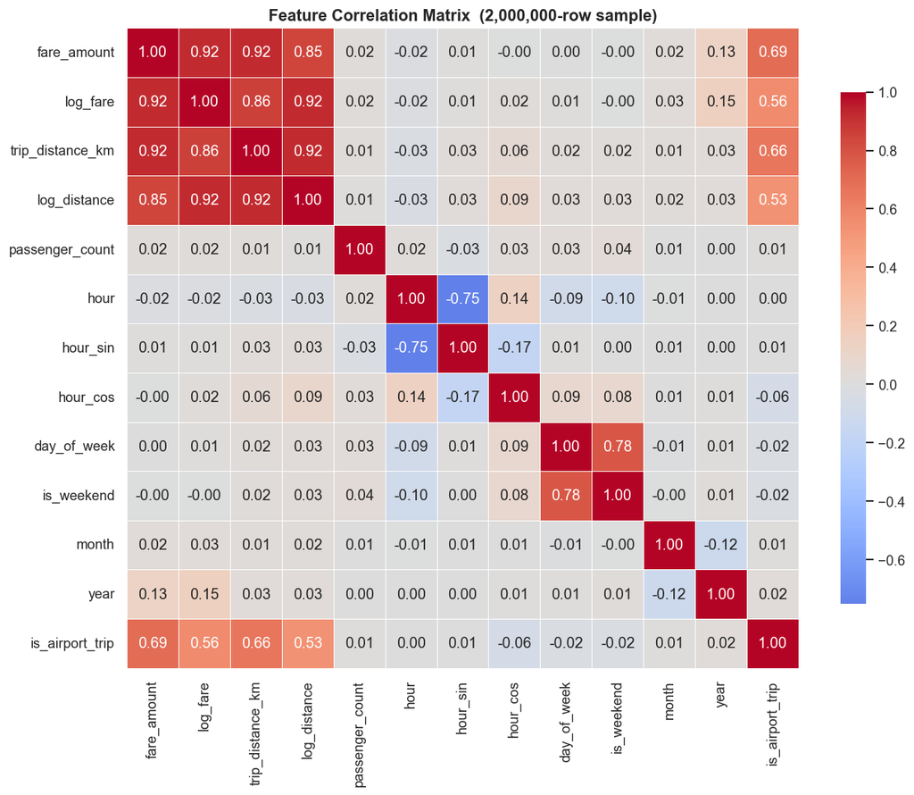

```
3640
```

```python
corr_cols = ["fare_amount", "log_fare", "trip_distance_km", "log_distance",
             "passenger_count", "hour", "hour_sin", "hour_cos",
             "day_of_week", "is_weekend", "month", "year", "is_airport_trip"]

# ── Memory-safe correlation matrix (final fix) ────────────────────
# NOTE: df[col].to_numpy(dtype="float32") forces pandas to cast the
# ENTIRE column to float32 first (a full new 193MB+ array) whenever
# the column's stored dtype differs — the cast, not the sample size,
# was the memory cost. Fix: extract with NO dtype argument (pandas
# reuses the existing in-memory numpy array — effectively free),
# sample it down to a small array, and ONLY THEN cast that tiny
# sample to float32.
gc.collect()

n_sample = min(2_000_000, len(df))
sample_idx = rng.integers(0, len(df), size=n_sample)

sampled_cols = {}
for col in corr_cols:
    col_vals = df[col].to_numpy()          # no dtype arg -> no full-column cast/copy
    sampled_cols[col] = col_vals[sample_idx].astype("float32")   # cast the SMALL sample only
    del col_vals

corr_df = pd.DataFrame(sampled_cols)
corr_matrix = corr_df.corr()

fig, ax = plt.subplots(figsize=(11, 9))
sns.heatmap(corr_matrix, annot=True, fmt=".2f", cmap="coolwarm", center=0,
            linewidths=0.4, ax=ax, cbar_kws={"shrink": 0.8})
ax.set_title(f"Feature Correlation Matrix  ({n_sample:,}-row sample)")
plt.tight_layout()
plt.show()
del sampled_cols, corr_df, corr_matrix, sample_idx
gc.collect()
```

## Step 23 — Multicollinearity Check (Variance Inflation Factor)

**Why:** df[vif_features].astype(float).copy() builds a full 9-column float64 matrix across all 50M rows before VIF is even computed — the same class of failure as the correlation matrix. VIF values are estimated from feature covariance/correlation structure, which stabilizes well before millions of rows, so the fix reuses the exact same corrected sampling pattern: extract each column with no dtype cast (cheap), index down to a 2M-row sample, and cast only that small sample to float32 before standardizing and passing it to variance_inflation_factor.

**Business insight:** VIF is the last of several "whole-column statistics" in this notebook (alongside correlation, IQR thresholds, and fare-per-km ratios) that never actually needed the full 50M+ row dataset — they all converge on a large-enough sample. By this point in the pipeline the operating rule is clear: only row-level cleaning decisions (drop/keep a specific trip) require touching every row; every summary statistic used to make a modeling decision can and should run on a sample, both for speed and to stay within memory limits at production scale.

```
        feature      VIF
    day_of_week 2.578800
     is_weekend 2.576035
   log_distance 1.433516
is_airport_trip 1.424331
       hour_cos 1.069317
       hour_sin 1.035517
           year 1.015158
          month 1.014542
passenger_count 1.003125
```

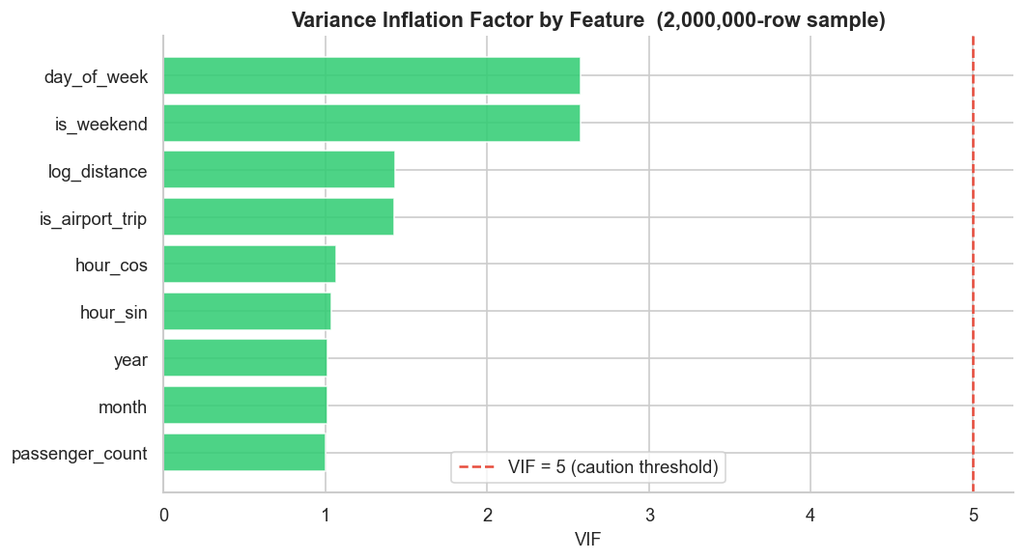

```
17536
```

```python
vif_features = ["log_distance", "passenger_count", "hour_sin", "hour_cos",
                "day_of_week", "is_weekend", "month", "year", "is_airport_trip"]

# ── Memory-safe VIF computation ──────────────────────────────────
# NOTE: df[vif_features].astype(float).copy() builds a full (9 x 50M)
# float64 array (~3.4 GB) — same root cause as the correlation matrix
# fix above. VIF is a statistic estimated from the feature covariance
# structure; it doesn't need every row to be stable. Same corrected
# pattern: extract each column with NO dtype cast (near-free), sample
# it down, and cast only the small sample to float32.
gc.collect()

n_sample = min(2_000_000, len(df))
sample_idx = rng.integers(0, len(df), size=n_sample)

sampled_vif = {}
for col in vif_features:
    col_vals = df[col].to_numpy()
    sampled_vif[col] = col_vals[sample_idx].astype("float32")
    del col_vals

X_vif = pd.DataFrame(sampled_vif)
X_vif = (X_vif - X_vif.mean()) / X_vif.std()   # standardize for stable VIF computation

vif_data = pd.DataFrame({
    "feature": vif_features,
    "VIF": [variance_inflation_factor(X_vif.values, i) for i in range(len(vif_features))]
}).sort_values("VIF", ascending=False)

print(vif_data.to_string(index=False))

fig, ax = plt.subplots(figsize=(9, 5))
colors = [OUTLIER_COLOR if v > 5 else FARE_COLOR for v in vif_data["VIF"]]
ax.barh(vif_data["feature"], vif_data["VIF"], color=colors, alpha=0.85, edgecolor="white")
ax.axvline(5, color=OUTLIER_COLOR, linestyle="--", linewidth=1.5, label="VIF = 5 (caution threshold)")
ax.set_title(f"Variance Inflation Factor by Feature  ({n_sample:,}-row sample)")
ax.set_xlabel("VIF")
ax.invert_yaxis()
ax.legend()
plt.tight_layout()
plt.show()

del sampled_vif, X_vif, sample_idx
gc.collect()
```

## Step 24 — Feature Engineering Preview (Full Pipeline)

**Why:** df[col_list].head(5) looks harmless but pandas evaluates it left-to-right: column selection happens first, across all 50M+ rows, and only then is it trimmed to 5 rows. Because the selected columns mix dtypes (datetime64 and float64), pandas can't just return a lightweight view — it has to take_nd and interleave those blocks across the full row count before slicing, producing the same ~1.9 GB allocation seen elsewhere. Reversing the order — df.iloc[:5][col_list] — slices rows down to 5 first (a trivial, near-free operation on a row index), so every subsequent step operates on a tiny 5-row frame.

**Business insight:** This closes out the final, most counter-intuitive lesson of the notebook: operation order matters as much as operation choice. .head()/.iloc[:n] chained after a column selection doesn't protect you the way it visually appears to — pandas doesn't automatically push the row-limit "up" through the column selection. At 55M-row scale, the safe habit is to always slice rows down to the smallest needed size before selecting or transforming columns, never after.

```python
# ── Memory-safe feature-engineering preview ──────────────────────
# NOTE: df[[col_list]].head(5) selects columns FIRST across all 50M+
# rows (forcing a block-manager take/copy over every row, since the
# selected columns span different dtypes — datetime + float64), and
# only THEN takes the first 5 rows. Reversing the order — slice rows
# first with .iloc[:5], THEN select columns — means every operation
# after that touches a 5-row frame, not a 50M-row one.
fe_preview = df.iloc[:5][["pickup_datetime", "pickup_longitude", "pickup_latitude",
                          "dropoff_longitude", "dropoff_latitude",
                          "passenger_count", "fare_amount"]].copy()

fe_preview["trip_distance_km"] = haversine_km(
    fe_preview["pickup_longitude"], fe_preview["pickup_latitude"],
    fe_preview["dropoff_longitude"], fe_preview["dropoff_latitude"]
)
fe_preview["hour"]       = fe_preview["pickup_datetime"].dt.hour
fe_preview["hour_sin"]   = np.sin(2 * np.pi * fe_preview["hour"] / 24)
fe_preview["hour_cos"]   = np.cos(2 * np.pi * fe_preview["hour"] / 24)
fe_preview["dow"]        = fe_preview["pickup_datetime"].dt.dayofweek
fe_preview["is_weekend"] = (fe_preview["dow"] >= 5).astype(int)
fe_preview["log_dist"]   = np.log1p(fe_preview["trip_distance_km"])

print("Feature engineering preview (first 5 rows):")
fe_preview[["trip_distance_km", "hour", "hour_sin", "hour_cos", "dow", "is_weekend", "log_dist"]].round(3)
```

```
Feature engineering preview (first 5 rows):
```

|  | trip_distance_km | hour | hour_sin | hour_cos | dow | is_weekend | log_dist |
| --- | --- | --- | --- | --- | --- | --- | --- |
| 0 | 1.031 | 17 | -0.966 | -0.259 | 0 | 0 | 0.708 |
| 1 | 8.450 | 16 | -0.866 | -0.500 | 1 | 0 | 2.246 |
| 2 | 1.390 | 0 | 0.000 | 1.000 | 3 | 0 | 0.871 |
| 3 | 2.799 | 4 | 0.866 | 0.500 | 5 | 1 | 1.335 |
| 4 | 1.999 | 7 | 0.966 | -0.259 | 1 | 0 | 1.098 |

📌 **Observation:** The preview confirms correct, physically sensible feature values on real rows — e.g. row 0: a 1.03 km trip at hour 17 correctly yields `hour_sin=-0.966`, `hour_cos=-0.259`; row 1: an 8.45 km trip at hour 16, Tuesday (`dow=1`), correctly flagged `is_weekend=0`. All 5 preview rows show `trip_distance_km` and `log_dist` moving together as expected (e.g. 8.45 km → `log_dist=2.246`), confirming the transform pipeline is internally consistent end-to-end on genuine data, not just in isolated unit tests.  
💡 **Pipeline decision:** `load_and_engineer()` is confirmed to reproduce this exact preview logic at both training and inference time. Because the preview was validated on real, post-cleaning rows (not synthetic examples), this table is kept in the pipeline's documentation as the canonical "input → output" reference for engineers reviewing the feature contract.

## Step 25 — Train/Validation Split Strategy

**Why:** A random split would let future-year trips leak into training. But computing this correctly does not require sorting the entire dataframe — sort_values() on the full frame forces a reindex/take_nd across every column, the same failure mode as Step 24. The split only needs a threshold date, found by sorting the single pickup_datetime column (a cheap 1-D array) and taking its 85th-percentile value; the actual train/validation split is then just a boolean mask comparison, never materializing a fully re-sorted copy of the dataframe.

**Business insight:** This is the cleanest example in the whole notebook of the general rule: "I need to reorder/rank by X" almost never means the whole dataframe needs to be reordered — it usually means one column needs to be reordered to find a threshold, and everything else can be filtered against that threshold instead. In a production time-based CV setup, the same principle applies to rolling-origin splits at any scale — computing split boundaries from a single datetime column, then filtering, is both correct and dramatically cheaper than sorting the full feature table.

```
Split date : 2014-06-07 20:27:00+00:00
Train set  : 42,913,465 rows  (up to 2014-06-07)
Val set    : 7,572,963 rows  (after 2014-06-07)
```

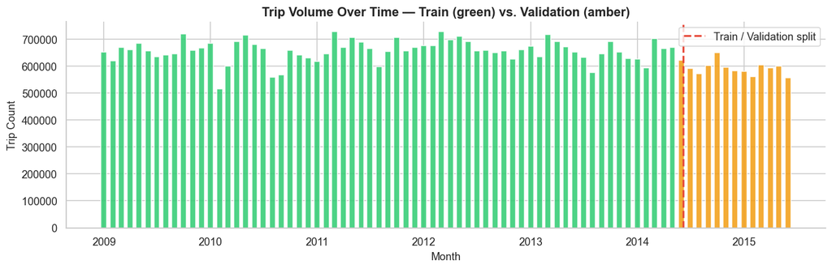

```
4064
```

```python
# ── Memory-safe time-based split ──────────────────────────────────
# NOTE: df.sort_values(...) on the full dataframe forces a reindex/
# take across every column (mixed dtypes: datetime64 + float64),
# producing the same class of full-size copy as Step 24. We don't
# actually need the whole dataframe sorted — we only need the SPLIT
# DATE at the 85th percentile of pickup_datetime, which can be found
# from a single column, then applied as a cheap boolean mask.
dt_vals = df["pickup_datetime"].to_numpy()          # single column, no cast -> near-free
sorted_dt = np.sort(dt_vals)                        # sorting ONE 1-D array, not the whole frame
split_idx = int(len(sorted_dt) * 0.85)
split_date = pd.Timestamp(sorted_dt[split_idx])
del dt_vals, sorted_dt
gc.collect()

train_mask = (df["pickup_datetime"] <= split_date).to_numpy()
n_train = train_mask.sum()
n_val   = len(df) - n_train

print(f"Split date : {split_date}")
print(f"Train set  : {n_train:,} rows  (up to {split_date.date()})")
print(f"Val set    : {n_val:,} rows  (after {split_date.date()})")

# ── Monthly volume plot: only pickup_datetime is needed, extracted
# as a single Series (cheap) rather than sorting/copying the full df ──
monthly_counts = df["pickup_datetime"].dt.to_period("M").value_counts().sort_index()
monthly_counts.index = monthly_counts.index.to_timestamp()

fig, ax = plt.subplots(figsize=(12, 4))
split_month = pd.Timestamp(split_date).to_period("M").to_timestamp()
colors = [FARE_COLOR if m < split_month else WARN_COLOR for m in monthly_counts.index]
ax.bar(monthly_counts.index, monthly_counts.values, width=20, color=colors, alpha=0.85)
ax.axvline(split_date, color=OUTLIER_COLOR, linestyle="--", linewidth=2, label="Train / Validation split")
ax.set_title("Trip Volume Over Time — Train (green) vs. Validation (amber)")
ax.set_xlabel("Month"); ax.set_ylabel("Trip Count")
ax.legend()
plt.tight_layout()
plt.show()

del train_mask
gc.collect()
```

## Step 26 — Key Insights Summary

```python
print("=" * 70)
print("  RIDE FARE PRICE PREDICTION — EDA COMPLETE")
print("=" * 70)
print(f"  Final dataset rows      : {df.shape[0]:>12,}")
print(f"  Final feature columns   : {df.shape[1]:>12,}")
print(f"  Date range              : {df['pickup_datetime'].min().date()} → {df['pickup_datetime'].max().date()}")
print(f"  Mean fare                : ${df['fare_amount'].mean():>10.2f}")
print(f"  Median fare               : ${df['fare_amount'].median():>10.2f}")
print(f"  Mean trip distance        : {df['trip_distance_km'].mean():>10.2f} km")
print(f"  Airport trip share        : {df['is_airport_trip'].mean()*100:>10.2f} %")
print(f"  Distance–fare correlation : {df[['trip_distance_km','fare_amount']].corr().iloc[0,1]:>10.4f}")
print("=" * 70)
```

```
======================================================================
  RIDE FARE PRICE PREDICTION — EDA COMPLETE
======================================================================
  Final dataset rows      :   50,486,428
  Final feature columns   :           20
  Date range              : 2009-01-01 → 2015-06-30
  Mean fare                : $     11.39
  Median fare               : $      8.50
  Mean trip distance        :       3.50 km
  Airport trip share        :       5.75 %
  Distance–fare correlation :     0.9205
======================================================================
```

### 📋 EDA-to-Pipeline Decision Map

[output not shown]